# HouseSellingPrices

```r
library(tidyverse)
library(mosaic)
library(car)
library(pander)
```

```r
train <- read.csv("C:/Users/.../OneDrive - BYU-Idaho/Documents/Math 425/house-prices-advanced-regression-techniques-1/train.csv", stringsAsFactors = TRUE)

train1 <- train %>%
  mutate(
    Alley = as.character(Alley),
    Alley = replace_na(Alley, "None"),
    Alley = as.factor(Alley),
    BsmtQual = as.character(BsmtQual),
    BsmtQual = replace_na(BsmtQual, "None"),
    BsmtQual = as.factor(BsmtQual),
    BsmtCond = as.character(BsmtCond),
    BsmtCond = replace_na(BsmtCond, "None"),
    BsmtCond = as.factor(BsmtCond),
    BsmtExposure = as.character(BsmtExposure),
    BsmtExposure = replace_na(BsmtExposure, "None"),
    BsmtExposure = as.factor(BsmtExposure),
    BsmtFinType1 = as.character(BsmtFinType1),
    BsmtFinType1 = replace_na(BsmtFinType1, "None"),
    BsmtFinType1 = as.factor(BsmtFinType1),
    BsmtFinType2 = as.character(BsmtFinType2),
    BsmtFinType2 = replace_na(BsmtFinType2, "None"),
    BsmtFinType2 = as.factor(BsmtFinType2),
    FireplaceQu = as.character(FireplaceQu),
    FireplaceQu = replace_na(FireplaceQu, "None"),
    FireplaceQu = as.factor(FireplaceQu),
    GarageType = as.character(GarageType),
    GarageType = replace_na(GarageType, "None"),
    GarageType = as.factor(GarageType),
    GarageFinish = as.character(GarageFinish),
    GarageFinish = replace_na(GarageFinish, "None"),
    GarageFinish = as.factor(GarageFinish),
    GarageQual = as.character(GarageQual),
    GarageQual = replace_na(GarageQual, "None"),
    GarageQual = as.factor(GarageQual),
    GarageCond = as.character(GarageCond),
    GarageCond = replace_na(GarageCond, "None"),
    GarageCond = as.factor(GarageCond),
    PoolQC = as.character(PoolQC),
    PoolQC = replace_na(PoolQC, "None"),
    PoolQC = as.factor(PoolQC),
    Fence = as.character(Fence),
    Fence = replace_na(Fence, "None"),
    Fence = as.factor(Fence),
    MiscFeature = as.character(MiscFeature),
    MiscFeature = replace_na(MiscFeature, "None"),
    MiscFeature = as.factor(MiscFeature)
    )
```

```r
train2 <- train1 %>%
  mutate(
    bath_num = HalfBath + FullBath + BsmtFullBath + BsmtHalfBath,
    total_sqft = TotalBsmtSF + GrLivArea + GarageArea,
    neighborhood = case_when(
      #Neighborhood == "MeadowV" ~ "below_100",
      Neighborhood %in% c("MeadowV", "IDOTRR", "BrDale", "OldTown", "Edwards", "BrkSide", "Sawyer",
                          "Blueste", "SWISU", "NAmes", "NPkVill", "Mitchel", "SawyerW",
                          "Gilbert", "NWAmes", "Blmngtn", "CollgCr") ~ 0,
      Neighborhood %in% c("ClearCr", "Crawfor", "Veenker", "Somerst", "Timber", "StoneBr") ~ 1,
      Neighborhood %in% c("NoRidge", "NridgHt") ~ 2),
    pool = case_when(
      PoolQC %in% c("Fa", "TA", "Gd", "Ex") ~ 1,
      PoolQC %in% c("None") ~ 0),
    re_model = YrSold - YearBuilt,
    deck_sqft = WoodDeckSF + OpenPorchSF + EnclosedPorch + ScreenPorch,
    sqft_per_room = GrLivArea / TotRmsAbvGrd,
    area = LotFrontage + LotArea,
    area_sqft_ratio = LotArea / total_sqft,
    basement = case_when(
      BsmtQual %in% "Ex" ~ 5,
      BsmtQual %in% "Gd" ~ 4,
      BsmtQual %in% "TA" ~ 3,
      BsmtQual %in% "Fa" ~ 2,
      BsmtQual %in% "Po" ~ 1,
      BsmtQual %in% "None" ~ 0),
    year_sold = case_when(
      YrSold %in% c(2006, 2007) ~ "Before_Crash",
      YrSold %in% c(2008,2009) ~ "Crash",
      YrSold %in% 2010 ~ "After Crash"),
    kitchen = case_when(
      KitchenQual %in% "Ex" ~ 4,
      KitchenQual %in% "Gd" ~ 3,
      KitchenQual %in% "TA" ~ 2,
      KitchenQual %in% "Fa" ~ 1,
      KitchenQual %in% "Po" ~ 0),
    building = case_when(
      BldgType %in% c("1Fam", "TwnhsE") ~ 1,
      BldgType %in% c("2FmCon", "Duplex", "Twnhs", "Duplx", "TwnhsI", "2fmCon") ~ 0),
    ac = case_when(
      CentralAir %in% "Y" ~ 1,
      CentralAir %in% "N" ~ 0)
  )
```

## Scratchwork

```r
# Low outlier
train[1299, ]
```

```
##        Id MSSubClass MSZoning LotFrontage LotArea Street Alley LotShape
## 1299 1299         60       RL         313   63887   Pave  <NA>      IR3
##      LandContour Utilities LotConfig LandSlope Neighborhood Condition1
## 1299         Bnk    AllPub    Corner       Gtl      Edwards      Feedr
##      Condition2 BldgType HouseStyle OverallQual OverallCond YearBuilt
## 1299       Norm     1Fam     2Story          10           5      2008
##      YearRemodAdd RoofStyle RoofMatl Exterior1st Exterior2nd MasVnrType
## 1299         2008       Hip  ClyTile      Stucco      Stucco      Stone
##      MasVnrArea ExterQual ExterCond Foundation BsmtQual BsmtCond BsmtExposure
## 1299        796        Ex        TA      PConc       Ex       TA           Gd
##      BsmtFinType1 BsmtFinSF1 BsmtFinType2 BsmtFinSF2 BsmtUnfSF TotalBsmtSF
## 1299          GLQ       5644          Unf          0       466        6110
##      Heating HeatingQC CentralAir Electrical X1stFlrSF X2ndFlrSF LowQualFinSF
## 1299    GasA        Ex          Y      SBrkr      4692       950            0
##      GrLivArea BsmtFullBath BsmtHalfBath FullBath HalfBath BedroomAbvGr
## 1299      5642            2            0        2        1            3
##      KitchenAbvGr KitchenQual TotRmsAbvGrd Functional Fireplaces FireplaceQu
## 1299            1          Ex           12        Typ          3          Gd
##      GarageType GarageYrBlt GarageFinish GarageCars GarageArea GarageQual
## 1299     Attchd        2008          Fin          2       1418         TA
##      GarageCond PavedDrive WoodDeckSF OpenPorchSF EnclosedPorch X3SsnPorch
## 1299         TA          Y        214         292             0          0
##      ScreenPorch PoolArea PoolQC Fence MiscFeature MiscVal MoSold YrSold
## 1299           0      480     Gd  <NA>        <NA>       0      1   2008
##      SaleType SaleCondition SalePrice
## 1299      New       Partial    160000
```

```r
# High outlier
train[1183, ]
```

```
##        Id MSSubClass MSZoning LotFrontage LotArea Street Alley LotShape
## 1183 1183         60       RL         160   15623   Pave  <NA>      IR1
##      LandContour Utilities LotConfig LandSlope Neighborhood Condition1
## 1183         Lvl    AllPub    Corner       Gtl      NoRidge       Norm
##      Condition2 BldgType HouseStyle OverallQual OverallCond YearBuilt
## 1183       Norm     1Fam     2Story          10           5      1996
##      YearRemodAdd RoofStyle RoofMatl Exterior1st Exterior2nd MasVnrType
## 1183         1996       Hip  CompShg     Wd Sdng     ImStucc       None
##      MasVnrArea ExterQual ExterCond Foundation BsmtQual BsmtCond BsmtExposure
## 1183          0        Gd        TA      PConc       Ex       TA           Av
##      BsmtFinType1 BsmtFinSF1 BsmtFinType2 BsmtFinSF2 BsmtUnfSF TotalBsmtSF
## 1183          GLQ       2096          Unf          0       300        2396
##      Heating HeatingQC CentralAir Electrical X1stFlrSF X2ndFlrSF LowQualFinSF
## 1183    GasA        Ex          Y      SBrkr      2411      2065            0
##      GrLivArea BsmtFullBath BsmtHalfBath FullBath HalfBath BedroomAbvGr
## 1183      4476            1            0        3        1            4
##      KitchenAbvGr KitchenQual TotRmsAbvGrd Functional Fireplaces FireplaceQu
## 1183            1          Ex           10        Typ          2          TA
##      GarageType GarageYrBlt GarageFinish GarageCars GarageArea GarageQual
## 1183     Attchd        1996          Fin          3        813         TA
##      GarageCond PavedDrive WoodDeckSF OpenPorchSF EnclosedPorch X3SsnPorch
## 1183         TA          Y        171          78             0          0
##      ScreenPorch PoolArea PoolQC Fence MiscFeature MiscVal MoSold YrSold
## 1183           0      555     Ex MnPrv        <NA>       0      7   2007
##      SaleType SaleCondition SalePrice
## 1183       WD       Abnorml    745000
```

```r
# Mid
train[1000, ]
```

```
##        Id MSSubClass MSZoning LotFrontage LotArea Street Alley LotShape
## 1000 1000         20       RL          64    6762   Pave  <NA>      Reg
##      LandContour Utilities LotConfig LandSlope Neighborhood Condition1
## 1000         Lvl    AllPub    Inside       Gtl      CollgCr       Norm
##      Condition2 BldgType HouseStyle OverallQual OverallCond YearBuilt
## 1000       Norm     1Fam     1Story           7           5      2006
##      YearRemodAdd RoofStyle RoofMatl Exterior1st Exterior2nd MasVnrType
## 1000         2006     Gable  CompShg     VinylSd     VinylSd      Stone
##      MasVnrArea ExterQual ExterCond Foundation BsmtQual BsmtCond BsmtExposure
## 1000         24        Gd        TA      PConc       Gd       TA           Av
##      BsmtFinType1 BsmtFinSF1 BsmtFinType2 BsmtFinSF2 BsmtUnfSF TotalBsmtSF
## 1000          GLQ        686          Unf          0       501        1187
##      Heating HeatingQC CentralAir Electrical X1stFlrSF X2ndFlrSF LowQualFinSF
## 1000    GasA        Ex          Y      SBrkr      1208         0            0
##      GrLivArea BsmtFullBath BsmtHalfBath FullBath HalfBath BedroomAbvGr
## 1000      1208            1            0        2        0            2
##      KitchenAbvGr KitchenQual TotRmsAbvGrd Functional Fireplaces FireplaceQu
## 1000            1          Gd            6        Typ          0        <NA>
##      GarageType GarageYrBlt GarageFinish GarageCars GarageArea GarageQual
## 1000     Attchd        2006          RFn          2        632         TA
##      GarageCond PavedDrive WoodDeckSF OpenPorchSF EnclosedPorch X3SsnPorch
## 1000         TA          Y        105          61             0          0
##      ScreenPorch PoolArea PoolQC Fence MiscFeature MiscVal MoSold YrSold
## 1000           0        0   <NA>  <NA>        <NA>       0      2   2010
##      SaleType SaleCondition SalePrice
## 1000       WD        Normal    206000
```

```r
train[633, ]
```

```
##      Id MSSubClass MSZoning LotFrontage LotArea Street Alley LotShape
## 633 633         20       RL          85   11900   Pave  <NA>      Reg
##     LandContour Utilities LotConfig LandSlope Neighborhood Condition1
## 633         Lvl    AllPub    Inside       Gtl       NWAmes       Norm
##     Condition2 BldgType HouseStyle OverallQual OverallCond YearBuilt
## 633       Norm     1Fam     1Story           7           5      1977
##     YearRemodAdd RoofStyle RoofMatl Exterior1st Exterior2nd MasVnrType
## 633         1977       Hip  CompShg     Plywood     Plywood    BrkFace
##     MasVnrArea ExterQual ExterCond Foundation BsmtQual BsmtCond BsmtExposure
## 633        209        TA        Gd     CBlock       TA       TA           No
##     BsmtFinType1 BsmtFinSF1 BsmtFinType2 BsmtFinSF2 BsmtUnfSF TotalBsmtSF
## 633          ALQ        822          Unf          0       564        1386
##     Heating HeatingQC CentralAir Electrical X1stFlrSF X2ndFlrSF LowQualFinSF
## 633    GasA        TA          Y      SBrkr      1411         0            0
##     GrLivArea BsmtFullBath BsmtHalfBath FullBath HalfBath BedroomAbvGr
## 633      1411            0            0        2        0            3
##     KitchenAbvGr KitchenQual TotRmsAbvGrd Functional Fireplaces FireplaceQu
## 633            1          TA            6        Typ          1          TA
##     GarageType GarageYrBlt GarageFinish GarageCars GarageArea GarageQual
## 633     Attchd        1977          Fin          2        544         TA
##     GarageCond PavedDrive WoodDeckSF OpenPorchSF EnclosedPorch X3SsnPorch
## 633         TA          Y        192           0             0          0
##     ScreenPorch PoolArea PoolQC Fence MiscFeature MiscVal MoSold YrSold
## 633           0        0   <NA>  <NA>        <NA>       0      4   2009
##     SaleType SaleCondition SalePrice
## 633       WD        Family     82500
```

```r
neighbor_value <- train2 %>%
  group_by(Neighborhood) %>%
  summarise(
    mean_price = median(SalePrice),
    mean_sqft = median(total_sqft))
```

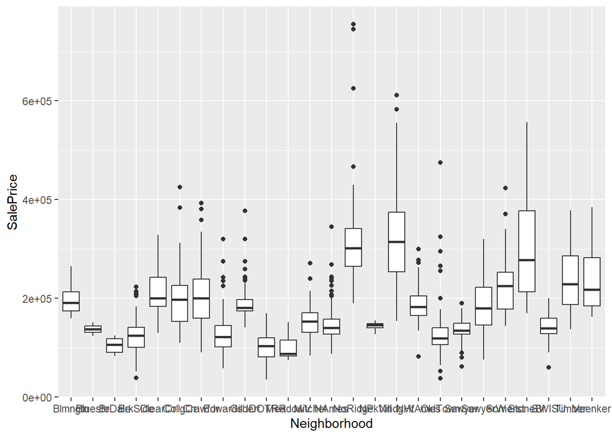

```r
ggplot(train2, aes(x=Neighborhood, y=SalePrice)) +
  geom_boxplot()
```

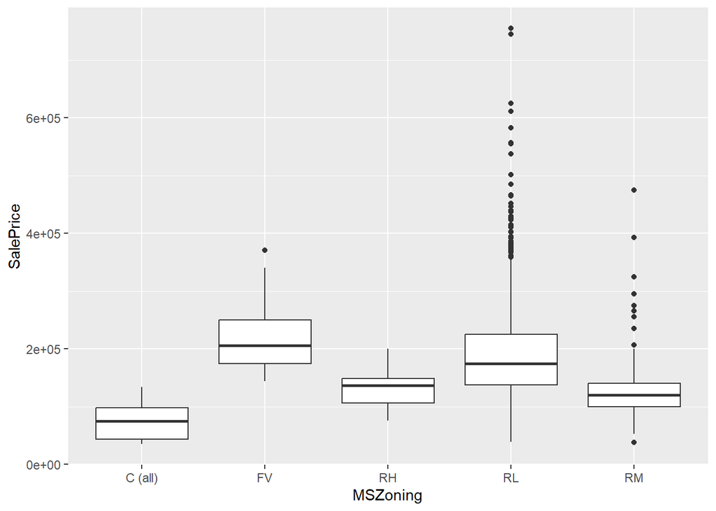

```r
ggplot(train, aes(x=MSZoning, y=SalePrice)) +
  geom_boxplot()
```

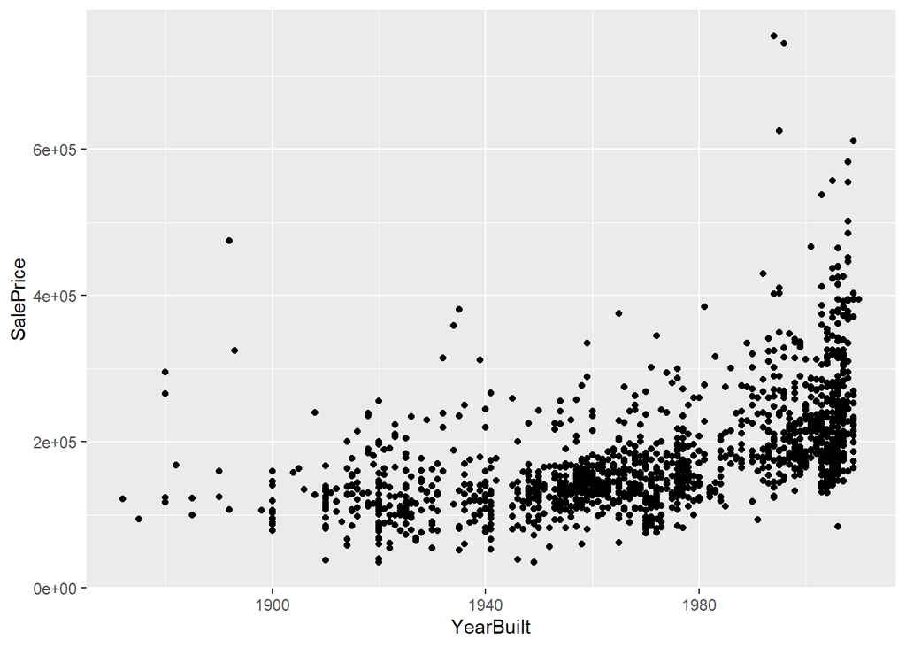

```r
ggplot(train, aes(x=YearBuilt, y=SalePrice)) +
  geom_point()
```

```r
apply(train2, 2, function(x) sum(is.na(x)))
```

```
##              Id      MSSubClass        MSZoning     LotFrontage         LotArea
##               0               0               0             259               0
##          Street           Alley        LotShape     LandContour       Utilities
##               0               0               0               0               0
##       LotConfig       LandSlope    Neighborhood      Condition1      Condition2
##               0               0               0               0               0
##        BldgType      HouseStyle     OverallQual     OverallCond       YearBuilt
##               0               0               0               0               0
##    YearRemodAdd       RoofStyle        RoofMatl     Exterior1st     Exterior2nd
##               0               0               0               0               0
##      MasVnrType      MasVnrArea       ExterQual       ExterCond      Foundation
##               8               8               0               0               0
##        BsmtQual        BsmtCond    BsmtExposure    BsmtFinType1      BsmtFinSF1
##               0               0               0               0               0
##    BsmtFinType2      BsmtFinSF2       BsmtUnfSF     TotalBsmtSF         Heating
##               0               0               0               0               0
##       HeatingQC      CentralAir      Electrical       X1stFlrSF       X2ndFlrSF
##               0               0               1               0               0
##    LowQualFinSF       GrLivArea    BsmtFullBath    BsmtHalfBath        FullBath
##               0               0               0               0               0
##        HalfBath    BedroomAbvGr    KitchenAbvGr     KitchenQual    TotRmsAbvGrd
##               0               0               0               0               0
##      Functional      Fireplaces     FireplaceQu      GarageType     GarageYrBlt
##               0               0               0               0              81
##    GarageFinish      GarageCars      GarageArea      GarageQual      GarageCond
##               0               0               0               0               0
##      PavedDrive      WoodDeckSF     OpenPorchSF   EnclosedPorch      X3SsnPorch
##               0               0               0               0               0
##     ScreenPorch        PoolArea          PoolQC           Fence     MiscFeature
##               0               0               0               0               0
##         MiscVal          MoSold          YrSold        SaleType   SaleCondition
##               0               0               0               0               0
##       SalePrice        bath_num      total_sqft    neighborhood            pool
##               0               0               0               0               0
##        re_model       deck_sqft   sqft_per_room            area area_sqft_ratio
##               0               0               0             259               0
##        basement       year_sold         kitchen        building              ac
##               0               0               0               0               0
```

```r
set.seed(7)
#1211
#7
#16
num_rows <- 1000 #1460 total
keep <- sample(1:nrow(train), num_rows)

mytrain <- train2[keep, ] #Use this in the lm(..., data=mytrain) it is like "rbdata"

mytest <- train2[-keep, ] #Use this in the predict(..., newdata=mytest) it is like "mytrain"
```

```r
neighbor_value <- train2 %>%
  group_by(Neighborhood) %>%
  summarise(
    mean_price = median(SalePrice),
    mean_sqft = median(total_sqft))
```

```r
mylm <- lm(SalePrice ~ ac, data=train2)
summary(mylm)
```

```
##
## Call:
## lm(formula = SalePrice ~ ac, data = train2)
##
## Residuals:
##     Min      1Q  Median      3Q     Max
## -134187  -51187  -16187   30394  568813
##
## Coefficients:
##             Estimate Std. Error t value Pr(>|t|)
## (Intercept)   105264       7892  13.339   <2e-16 ***
## ac             80923       8162   9.915   <2e-16 ***
## ---
## Signif. codes:  0 '***' 0.001 '**' 0.01 '*' 0.05 '.' 0.1 ' ' 1
##
## Residual standard error: 76920 on 1458 degrees of freedom
## Multiple R-squared:  0.06317,    Adjusted R-squared:  0.06252
## F-statistic: 98.31 on 1 and 1458 DF,  p-value: < 2.2e-16
```

```r
# YearRemodAdd = 0.255
# YearBuilt = 0.3
```

```r
mylm.train <- lm(log(SalePrice) ~ total_sqft + neighborhood + bath_num + OverallQual + re_model + kitchen + ac + TotRmsAbvGrd + Fireplaces + building + area_sqft_ratio, data=mytrain)
summary(mylm.train)
```

```
##
## Call:
## lm(formula = log(SalePrice) ~ total_sqft + neighborhood + bath_num +
##     OverallQual + re_model + kitchen + ac + TotRmsAbvGrd + Fireplaces +
##     building + area_sqft_ratio, data = mytrain)
##
## Residuals:
##      Min       1Q   Median       3Q      Max
## -2.03466 -0.06913  0.00823  0.08469  0.46179
##
## Coefficients:
##                   Estimate Std. Error t value Pr(>|t|)
## (Intercept)      1.052e+01  4.552e-02 231.013  < 2e-16 ***
## total_sqft       1.156e-04  9.157e-06  12.627  < 2e-16 ***
## neighborhood     7.297e-02  9.907e-03   7.366 3.70e-13 ***
## bath_num         5.498e-02  7.563e-03   7.270 7.29e-13 ***
## OverallQual      8.058e-02  6.241e-03  12.912  < 2e-16 ***
## re_model        -1.606e-03  2.400e-04  -6.693 3.65e-11 ***
## kitchen          5.610e-02  1.053e-02   5.326 1.25e-07 ***
## ac               1.348e-01  2.139e-02   6.303 4.39e-10 ***
## TotRmsAbvGrd     2.030e-02  4.346e-03   4.670 3.44e-06 ***
## Fireplaces       4.269e-02  9.008e-03   4.740 2.46e-06 ***
## building         1.080e-01  1.889e-02   5.716 1.44e-08 ***
## area_sqft_ratio  1.219e-02  2.001e-03   6.093 1.59e-09 ***
## ---
## Signif. codes:  0 '***' 0.001 '**' 0.01 '*' 0.05 '.' 0.1 ' ' 1
##
## Residual standard error: 0.1542 on 988 degrees of freedom
## Multiple R-squared:  0.8598, Adjusted R-squared:  0.8583
## F-statistic:   551 on 11 and 988 DF,  p-value: < 2.2e-16
```

```r
favstats(train$YrSold, data=train)
```

```
##   min   Q1 median   Q3  max     mean       sd    n missing
##  2006 2007   2008 2009 2010 2007.816 1.328095 1460       0
```

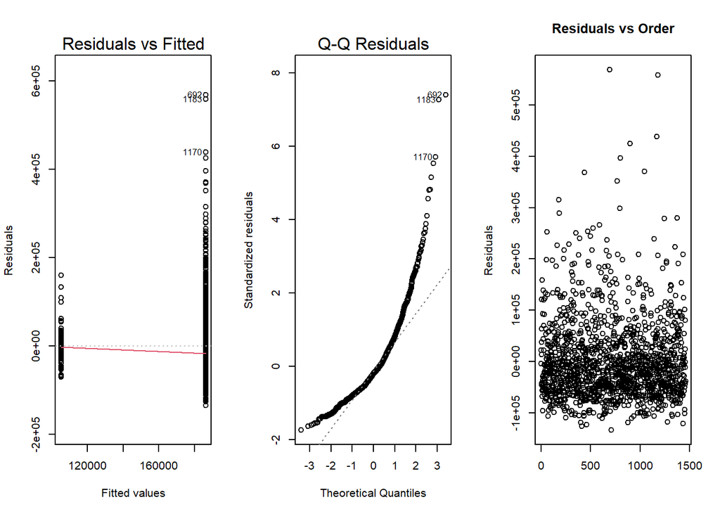

```r
par(mfrow=c(1,3))
plot(mylm, which=1:2)
plot(mylm$residuals, main="Residuals vs Order", xlab="",
     ylab="Residuals")
```

## Adjusted R-squared of Model on Mytrain data

```r
my_output_table <- data.frame(Model = "Current", `R^2` = round(summary(mylm.train)$r.squared,2), `Adjusted R^2` = round(summary(mylm.train)$adj.r.squared,2))

colnames(my_output_table) <- c("Model", "$R^2$", "Adjusted $R^2$")

knitr::kable(my_output_table)
```

| Model | $R^2$ | Adjusted $R^2$ |
| --- | --- | --- |
| Current | 0.86 | 0.86 |

## Adjusted R-squared of Model on Mytest data

```r
mytest$SalePrice <- log(mytest$SalePrice)
# Compute R-squared for each validation

  # Get y-hat for each model on new data.
  current_y <- predict(mylm.train, newdata=mytest)

  # Compute y-bar
  ybar <- mean(mytest$SalePrice) #Yi is given by Ynew from the new sample of data

  # Compute SSTO
  SSTO <- sum( (mytest$SalePrice - ybar)^2 )

  # Compute SSE for each model using y - yhat
  SSE_current <- sum( (mytest$SalePrice - current_y)^2 )

  # Compute R-squared for each
  rs_current <- 1 - SSE_current/SSTO

  # Compute adjusted R-squared for each
  n <- length(mytest$SalePrice) #sample size
  p_current <- length(coef(mylm.train)) #num. parameters in model
  rsa_current <- 1 - (n-1)/(n-p_current)*SSE_current/SSTO


my_output_table2 <- data.frame(Model = "Current", `Original R2` = round(summary(mylm.train)$r.squared,2), `Orig. Adj. R-squared` = round(summary(mylm.train)$adj.r.squared,2), `Validation R-squared` = round(rs_current, 2), `Validation Adj. R^2` = round(rsa_current,2))

colnames(my_output_table2) <- c("Model", "Original $R^2$", "Original Adj. $R^2$", "Validation $R^2$", "Validation Adj. $R^2$")

knitr::kable(my_output_table2, escape=TRUE, digits=4)
```

| Model | Original $R^2$ | Original Adj. $R^2$ | Validation $R^2$ | Validation Adj. $R^2$ |
| --- | --- | --- | --- | --- |
| Current | 0.86 | 0.86 | 0.85 | 0.84 |

## Graphing and Interpreting Model

```r
# Graphing
#mylm.test <- lm(log(SalePrice) ~ total_sqft + neighborhood + bath_num + OverallQual + re_model + kitchen + ac + TotRmsAbvGrd + Fireplaces + building + area_sqft_ratio, data=mytest)

b.log <- coef(mylm.train)
#stat_function(fun=function(x) exp(b.log[1] + b.log[2]*x), aes(color="orangered"))
#pander(b.log)
```

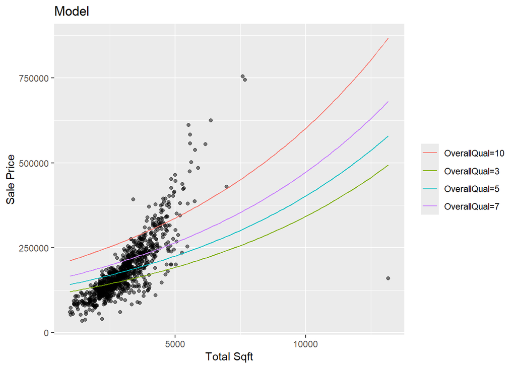

```r
#m(formula = log(SalePrice) ~ total_sqft + neighborhood + bath_num + OverallQual + re_model + kitchen + ac + TotRmsAbvGrd + Fireplaces + building + area_sqft_ratio, data = mytrain)

#stat_function(fun=function(x, x2=2, x3=2, x4=3, x5=10, x6=0, x7=4, x8=1, x9=3, x10=1, x11=1) exp(b.log[1] + b.log[2]*x + b.log[3]*x2 + b.log[4]*x3 + b.log[5]*x4 + b.log[6]*x5 + b.log[7]*x6 + b.log[8]*x7 + b.log[9]*x8 + b.log[10]*x9 + b.log[11]*x10 + b.log[12]*x11), color="steelblue")

# x1: total_sqft
# x2: neighborhood 0-2
# x3: bath_num
# x4: OverallQual 1-10
# x5: re_model
# x6: kitchen 0-4
# x7: ac 0-1
# x8: TotRmsAbvGrd
# x9: Fireplaces
# x10: building 0-1
# x11: area_sqft_area_ratio

ggplot(mytrain, aes(x=total_sqft, y=SalePrice)) +
  geom_point(alpha=0.5) +
  labs(x="Total Sqft", y="Sale Price", title = "Model") +
  stat_function(fun=function(x, x2=2, x3=3, x4=10, x5=0, x6=3, x7=1, x8=3, x9=1, x10=1, x11=0.3) exp(b.log[1] + b.log[2]*x + b.log[3]*x2 + b.log[4]*x3 + b.log[5]*x4 + b.log[6]*x5 + b.log[7]*x6 + b.log[8]*x7 + b.log[9]*x8 + b.log[10]*x9 + b.log[11]*x10 + b.log[12]*x11), aes(color="OverallQual=10")) +
  stat_function(fun=function(x, x2=2, x3=3, x4=7, x5=0, x6=3, x7=1, x8=3, x9=1, x10=1, x11=0.3) exp(b.log[1] + b.log[2]*x + b.log[3]*x2 + b.log[4]*x3 + b.log[5]*x4 + b.log[6]*x5 + b.log[7]*x6 + b.log[8]*x7 + b.log[9]*x8 + b.log[10]*x9 + b.log[11]*x10 + b.log[12]*x11), aes(color="OverallQual=7")) +
  stat_function(fun=function(x, x2=2, x3=3, x4=5, x5=0, x6=3, x7=1, x8=3, x9=1, x10=1, x11=0.3) exp(b.log[1] + b.log[2]*x + b.log[3]*x2 + b.log[4]*x3 + b.log[5]*x4 + b.log[6]*x5 + b.log[7]*x6 + b.log[8]*x7 + b.log[9]*x8 + b.log[10]*x9 + b.log[11]*x10 + b.log[12]*x11), aes(color="OverallQual=5")) +
  stat_function(fun=function(x, x2=2, x3=3, x4=3, x5=0, x6=3, x7=1, x8=3, x9=1, x10=1, x11=0.3) exp(b.log[1] + b.log[2]*x + b.log[3]*x2 + b.log[4]*x3 + b.log[5]*x4 + b.log[6]*x5 + b.log[7]*x6 + b.log[8]*x7 + b.log[9]*x8 + b.log[10]*x9 + b.log[11]*x10 + b.log[12]*x11), aes(color="OverallQual=3")) +
  theme(
    legend.title = element_blank())
```

```r
b <- exp(b.log)
pander(b.log)
```

Table continues below

| (Intercept) | total_sqft | neighborhood | bath_num | OverallQual | re_model |
| --- | --- | --- | --- | --- | --- |
| 10.52 | 0.0001156 | 0.07297 | 0.05498 | 0.08058 | -0.001606 |

| kitchen | ac | TotRmsAbvGrd | Fireplaces | building | area_sqft_ratio |
| --- | --- | --- | --- | --- | --- |
| 0.0561 | 0.1348 | 0.0203 | 0.04269 | 0.108 | 0.01219 |

```r
pander(b)
```

Table continues below

| (Intercept) | total_sqft | neighborhood | bath_num | OverallQual | re_model |
| --- | --- | --- | --- | --- | --- |
| 36906 | 1 | 1.076 | 1.057 | 1.084 | 0.9984 |

| kitchen | ac | TotRmsAbvGrd | Fireplaces | building | area_sqft_ratio |
| --- | --- | --- | --- | --- | --- |
| 1.058 | 1.144 | 1.021 | 1.044 | 1.114 | 1.012 |

The model predicts that any house in Ames, Iowa will have a starting value of 36,906 (the intercept). The graph above illustrates the impact of increasing the overall quality of a home (rated 1-10) in relation to its total square footage on the home’s price, while keeping all other attributes constant. Given that the coefficient for total square footage is approximately 1.000116, each additional square foot increases the predicted value by a factor of 1.000116. For instance, a house with 1,000 square feet would see its price rise to 41,445.53, adding 4,539.053 to the predicted price.

Considering the overall quality of the home, each 1-point increase in rating results in the house becoming 1.083914 times more expensive. Thus, a home with a quality rating of 10 would cost 82,613.45, adding $45,706.97 to the intercept price without accounting for anything else.

```r
# intercept
#exp(10.5161423455  + 0.0729745995*2 + 0.0549840201*3 + 0.0805788619*10 + -0.0016062592*0 + 0.0561019002*3 + 0.1348325889*1 + 0.0202954017*3 + 0.0426946173*1 + 0.1079727662*1 + 0.01218996122*0.3)
```

```r
# slope
#exp(0.0001156233*1000)
```